# Sensitivity analysis of COVID-19 cases imputation

Marina Espinasse

2023-04-28

In this file I will describe a simple sensitivity analysis of COVID-19 cases. In the cases data, there are many (50% and more depending on the month) cases recorded as “<5”. The idea is to replace these values with a random draw from a Uniform(1,4) distribution. But if we repeat this imputation 5 times, will datasets be too different from each other?

# 1 Load the dataset number 1

The 1st dataset was already created in the “01_data_preparation.RMD” file. Comments to what each code chunk does are also in the “01_data_preparation.RMD” file

```r
covid1 <- read.csv(here("output", "covid19_total_week_v1.csv"))
```

# 2 Create 4 additional datasets

I will run the same code 4 times changing the seed number, but no other changes will be made when creating COVID-19 total weekly count datasets.

Seeds used for the 5 datasets: 110323, 210423, 210424, 210425, 210426

```r
cases <- read.csv(here("data", "COVID19BE_CASES_MUNI.csv"))
```

```r
cases_prep <- cases |>
  filter(!is.na(NIS5)) |>
  select(c(NIS5, DATE, TX_DESCR_NL, PROVINCE, REGION, CASES)) |>
  rename(
    mcp_code = NIS5,
    mcp_name = TX_DESCR_NL,
    date = DATE,
    province = PROVINCE,
    region = REGION,
    cases = CASES
  ) |>
  mutate(
    year = lubridate::year(date),
    month = lubridate::month(date),
    day = lubridate::day(date),
    week = lubridate::week(date),
    cases = ifelse(cases == "<5", NA, cases),
    cases = as.numeric(cases)
  )
```

```r
days21 <- data.frame(date = seq(as.Date("2021-01-01"), as.Date("2021-12-31"), by = "+1 day"))

set.seed(210426)

cases_prep2 <- cases_prep |>
  filter(year == "2021") |>
  mutate(date = as.Date(date)) |>
  select(c(mcp_code, date, mcp_name, province, region, cases)) |>
  rowwise() |>
  mutate(cases = if_else(is.na(cases),
    round(runif(1, min = 1, max = 4), 0),
    cases
  ))


cases_bymp <- split(cases_prep2, cases_prep2$mcp_code)
```

```r
cases_bymp_prep <- cases_bymp %>%
  purrr::map(., ~ right_join(.x, days21, by = "date")) %>%
  purrr::map(., ~ ungroup(.x)) %>%
  purrr::map(., ~ mutate(.x, mcp_code_new = rep(mcp_code[1], 365) )) %>%
  purrr::map(., ~ mutate(.x, mcp_name_new = rep(mcp_name[1], 365))) %>%
  purrr::map(., ~ mutate(.x, province_new = rep(province[1], 365))) %>%
  purrr::map(., ~ mutate(.x, region_new = rep(region[1], 365)))
```

```r
cases_filled <- do.call("rbind", cases_bymp_prep)

cases_filled_prep <- cases_filled |>
  select(c(date, mcp_code_new, mcp_name_new,
           province_new, region_new, cases)) |>
  rename(mcp_code = mcp_code_new,
         mcp_name = mcp_name_new,
         province = province_new,
         region = region_new) |>
  mutate(
    year = lubridate::year(date),
    month = lubridate::month(date),
    day = lubridate::day(date),
    week = lubridate::week(date))
```

```r
cases_filled_prep2 <- cases_filled_prep |>
  mutate(cases = ifelse(is.na(cases),
                        0,
                        cases))
```

```r
cases_per_week <- cases_filled_prep2 |>
  mutate(week = ifelse(week == 53, 52, week)) |>
 group_by(mcp_code, mcp_name, province, region, week) |>
  summarize(cases_per_week = sum(cases)) |>
  rename(week_num = week)
```

```r
#write.csv(cases_per_week, file = "./output/covid19_total_week_v5.csv")
```

# 3 Compare summary statistics between the 5 datasets

```r
covid2 <- read.csv(here("output", "covid19_total_week_v2.csv"))
covid3 <- read.csv(here("output", "covid19_total_week_v3.csv"))
covid4 <- read.csv(here("output", "covid19_total_week_v4.csv"))
covid5 <- read.csv(here("output", "covid19_total_week_v5.csv"))
```

```r
stats1 <- mosaic::fav_stats(covid1$cases_per_week)
stats2 <- mosaic::fav_stats(covid2$cases_per_week)
stats3 <- mosaic::fav_stats(covid3$cases_per_week)
stats4 <- mosaic::fav_stats(covid4$cases_per_week)
stats5 <- mosaic::fav_stats(covid5$cases_per_week)

summary_stats <-rbind(stats1, stats2, stats3, stats4, stats5)
rownames(summary_stats) <- c(1,2,3,4,5)
kable(summary_stats) |>
  kable_styling("hover")
```

| min | Q1 | median | Q3 | max | mean | sd | n | missing |
| --- | --- | --- | --- | --- | --- | --- | --- | --- |
| 0 | 9 | 19 | 45 | 3875 | 49.22306 | 112.9752 | 30212 | 0 |
| 0 | 9 | 18 | 45 | 3875 | 49.22276 | 112.9791 | 30212 | 0 |
| 0 | 9 | 18 | 45 | 3875 | 49.22779 | 112.9745 | 30212 | 0 |
| 0 | 9 | 18 | 45 | 3875 | 49.22385 | 112.9776 | 30212 | 0 |
| 0 | 9 | 19 | 45 | 3875 | 49.20998 | 112.9828 | 30212 | 0 |

Because imputed values are only in the lower tail of the cases distribution (less than the 1st quartile), the mean and range is not affected. Variances are affected only decimally.

We may also compare the distributions of imputed COVID-19 cases

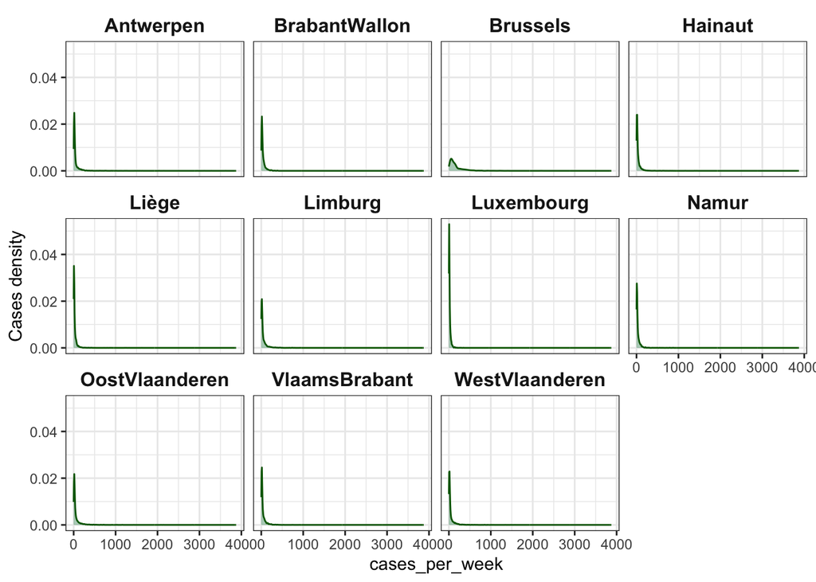

```r
dist1 <- ggplot(data = covid1,
               aes(x=cases_per_week)) +
  geom_density(alpha=0.4, fill="seagreen", color="darkgreen") +
  facet_wrap(.~ province) +
  theme_bw() +
  theme(strip.background = element_rect(color = "white", fill = "white"),
        strip.text = element_text(size=12, face = "bold")) +
  labs(y = "Cases density", "COVID19 cases")
dist1
```

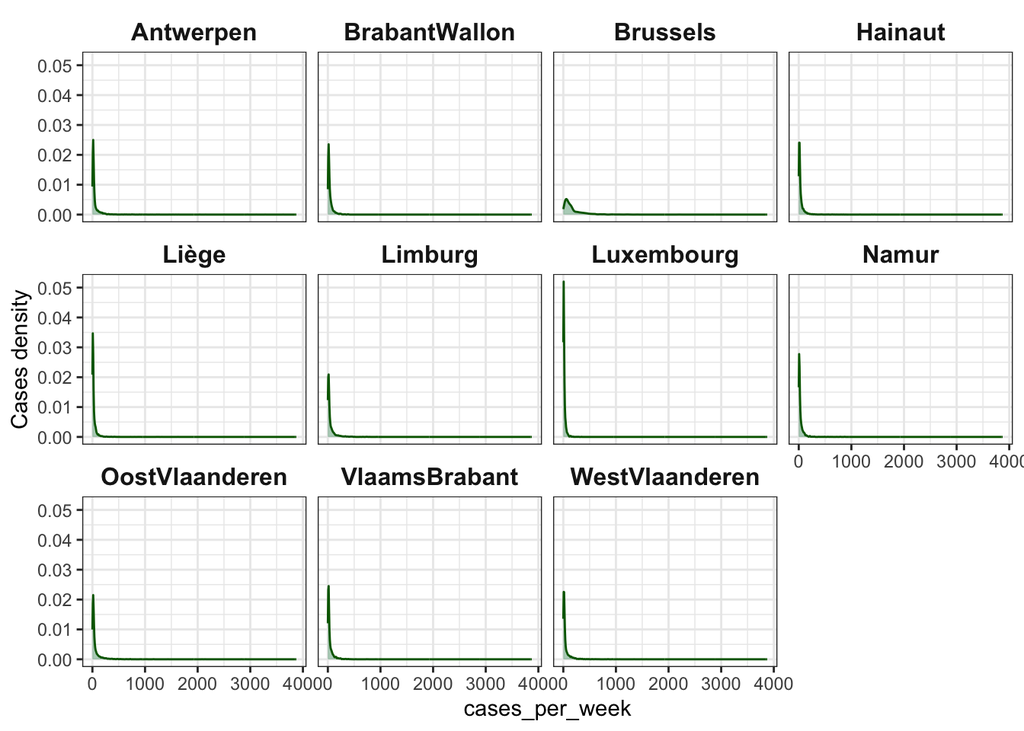

```r
dist2 <- ggplot(data = covid2,
               aes(x=cases_per_week)) +
  geom_density(alpha=0.4, fill="seagreen", color="darkgreen") +
  facet_wrap(.~ province) +
  theme_bw() +
  theme(strip.background = element_rect(color = "white", fill = "white"),
        strip.text = element_text(size=12, face = "bold")) +
  labs(y = "Cases density", "COVID19 cases")
dist2
```

Not obvious that imputation of the smallest values have any effect on the overall distribution of cases. Also, it is most likely that pollution will be related to larger than 5 counts of COVID-19, so the changes the distribution of lower than 5 values.